# Basic Classification Algorithms

```
Author:
Zach Wolpe
zachcolinwolpe@gmail.com
www.zachwolpe.com
```

Here is a collection of a number of entry level classification algorithm skeletons. Including:

```
- Logistic Regression
- KNN: K-Nearest Neighbors
- SVM: Support Vector Machines
- Kernal SVM
- Naive Bayes
- Decision Tree Classifier
- Random Forest Classification
```

## Model Evaluation

After introducing the abovementioned models, some basic model evaluation techniques are presented.

# Logistic Regression

A regression model that is $\in[0,1]$ bound, essentially modeling probabilities. Thereafter some cutoff value can be used to split the predicted value $(\hat{y})$ into successes $1$ & failures $0$.

This is done by modeling the $\ln(odds)$, where $odds = \frac{p}{1-p}$ where $p$ is the probability of success.

Fitting the logs odds is analogous to applying an activation function to ensure:

$$\hat{Y} \in [0,1]$$

#### Additional Notes

Logistic Regression is a linear classifier (separates the data by a straight line).

Features are scaled to avoid overweighing variables.

```python
# Logistic Regression

# Importing the libraries
import numpy as np
import matplotlib.pyplot as plt
import pandas as pd
import warnings

warnings.filterwarnings('ignore')
plt.style.use('seaborn-darkgrid')
```

```python
# Importing the dataset
dataset = pd.read_csv('Social_Network_Ads.csv')
X = dataset.iloc[:, [2, 3]].values
y = dataset.iloc[:, 4].values

# Splitting the dataset into the Training set and Test set
from sklearn.model_selection import train_test_split
X_train, X_test, y_train, y_test = train_test_split(X, y, test_size = 0.25, random_state = 0)

# Feature Scaling
from sklearn.preprocessing import StandardScaler
sc = StandardScaler()
X_train = sc.fit_transform(X_train)
X_test = sc.transform(X_test)

print('')
print('Shape: ', dataset.shape)
print('')
print(dataset.head())
```

```
Shape:  (400, 5)

    User ID  Gender  Age  EstimatedSalary  Purchased
0  15624510    Male   19            19000          0
1  15810944    Male   35            20000          0
2  15668575  Female   26            43000          0
3  15603246  Female   27            57000          0
4  15804002    Male   19            76000          0
```

```python
# Fitting Logistic Regression to the Training set
from sklearn.linear_model import LogisticRegression
from sklearn.linear_model import LogisticRegression
classifier = LogisticRegression(random_state = 0)
classifier.fit(X_train, y_train)

# Predicting the Test set results
y_pred = classifier.predict(X_test)

# Making the Confusion Matrix
from sklearn.metrics import confusion_matrix
cm = confusion_matrix(y_test, y_pred)

print('')
print('confusion matrix:')
print(cm)
```

```
confusion matrix:
[[65  3]
 [ 8 24]]
```

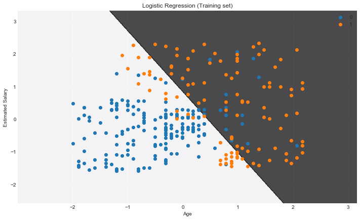

```python
# Visualising the Training set results
from matplotlib.colors import ListedColormap
plt.figure(figsize=(12,7))
X_set, y_set = X_train, y_train
X1, X2 = np.meshgrid(np.arange(start = X_set[:, 0].min() - 1, stop = X_set[:, 0].max() + 1, step = 0.01),
                     np.arange(start = X_set[:, 1].min() - 1, stop = X_set[:, 1].max() + 1, step = 0.01))
plt.contourf(X1, X2, classifier.predict(np.array([X1.ravel(), X2.ravel()]).T).reshape(X1.shape),
             alpha = 0.75,
             # cmap = ListedColormap(('red', 'green'))
            )
plt.xlim(X1.min(), X1.max())
plt.ylim(X2.min(), X2.max())
for i, j in enumerate(np.unique(y_set)):
    plt.scatter(X_set[y_set == j, 0], X_set[y_set == j, 1],
                # c = ListedColormap(('red', 'green'))(i),
                label = j)
plt.title('Logistic Regression (Training set)')
plt.xlabel('Age')
plt.ylabel('Estimated Salary')
plt.legend()
plt.show()
```

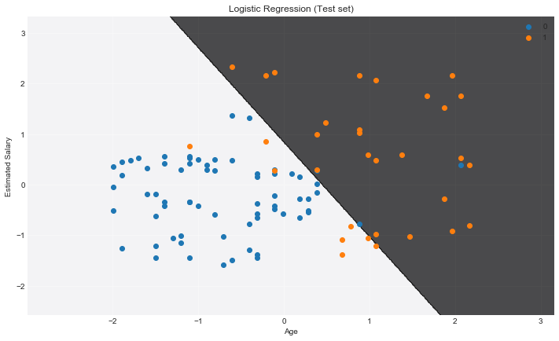

```python
# Visualising the Test set results
from matplotlib.colors import ListedColormap
plt.figure(figsize=(12,7))
X_set, y_set = X_test, y_test
X1, X2 = np.meshgrid(np.arange(start = X_set[:, 0].min() - 1, stop = X_set[:, 0].max() + 1, step = 0.01),
                     np.arange(start = X_set[:, 1].min() - 1, stop = X_set[:, 1].max() + 1, step = 0.01))
plt.contourf(X1, X2, classifier.predict(np.array([X1.ravel(), X2.ravel()]).T).reshape(X1.shape),
             alpha = 0.75,
            # cmap = ListedColormap(('red', 'green'))
            )
plt.xlim(X1.min(), X1.max())
plt.ylim(X2.min(), X2.max())
for i, j in enumerate(np.unique(y_set)):
    plt.scatter(X_set[y_set == j, 0], X_set[y_set == j, 1],
                # c = ListedColormap(('red', 'green'))(i),
                label = j)
plt.title('Logistic Regression (Test set)')
plt.xlabel('Age')
plt.ylabel('Estimated Salary')
plt.legend()
plt.show()
```

# KNN: K Nearest Neighbors

## Algorithm

```
- Initialize K, the number of neighbors in the dataset (commonly K=5)
- Take the K nearest neighbors (normally Euclidean distance but may be other) of a new datapoint and assign the new datapoint to the the category wherein the majority of its neighbors reside

(remember we are working with labelled data)
```

```python
# Importing the dataset
dataset = pd.read_csv('Social_Network_Ads.csv')
X = dataset.iloc[:, [2, 3]].values
y = dataset.iloc[:, 4].values

# Splitting the dataset into the Training set and Test set
from sklearn.model_selection import train_test_split
X_train, X_test, y_train, y_test = train_test_split(X, y, test_size = 0.25, random_state = 0)

# Feature Scaling
from sklearn.preprocessing import StandardScaler
sc = StandardScaler()
X_train = sc.fit_transform(X_train)
X_test = sc.transform(X_test)

print('')
print('Shape: ', dataset.shape)
print('')
print(dataset.head())
```

```
Shape:  (400, 5)

    User ID  Gender  Age  EstimatedSalary  Purchased
0  15624510    Male   19            19000          0
1  15810944    Male   35            20000          0
2  15668575  Female   26            43000          0
3  15603246  Female   27            57000          0
4  15804002    Male   19            76000          0
```

```python
# Fitting K-NN to the Training set
from sklearn.neighbors import KNeighborsClassifier
classifier = KNeighborsClassifier(n_neighbors = 5, metric = 'minkowski', p = 2)
classifier.fit(X_train, y_train)

# Predicting the Test set results
y_pred = classifier.predict(X_test)

# Making the Confusion Matrix
from sklearn.metrics import confusion_matrix
cm = confusion_matrix(y_test, y_pred)


print('')
print('confusion matrix:')
print('')
print(cm)
print('')
```

```
confusion matrix:

[[64  4]
 [ 3 29]]
```

[output not shown]

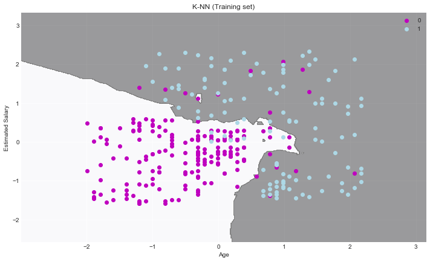

```python
# Visualising the Training set results
from matplotlib.colors import ListedColormap
plt.figure(figsize=(12,7))
X_set, y_set = X_train, y_train
X1, X2 = np.meshgrid(np.arange(start = X_set[:, 0].min() - 1, stop = X_set[:, 0].max() + 1, step = 0.01),
                     np.arange(start = X_set[:, 1].min() - 1, stop = X_set[:, 1].max() + 1, step = 0.01))
plt.contourf(X1, X2, classifier.predict(np.array([X1.ravel(), X2.ravel()]).T).reshape(X1.shape),
             alpha = 0.75, cmap = ListedColormap(('white', 'grey')))
plt.xlim(X1.min(), X1.max())
plt.ylim(X2.min(), X2.max())
for i, j in enumerate(np.unique(y_set)):
    plt.scatter(X_set[y_set == j, 0], X_set[y_set == j, 1],
                c = ListedColormap(('m', 'lightblue'))(i),
                label = j)
plt.title('K-NN (Training set)')
plt.xlabel('Age')
plt.ylabel('Estimated Salary')
plt.legend()
plt.show()
```

[output not shown]

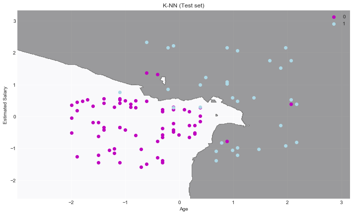

```python
# Visualising the Test set results
from matplotlib.colors import ListedColormap
plt.figure(figsize=(12,7))
X_set, y_set = X_test, y_test
X1, X2 = np.meshgrid(np.arange(start = X_set[:, 0].min() - 1, stop = X_set[:, 0].max() + 1, step = 0.01),
                     np.arange(start = X_set[:, 1].min() - 1, stop = X_set[:, 1].max() + 1, step = 0.01))
plt.contourf(X1, X2, classifier.predict(np.array([X1.ravel(), X2.ravel()]).T).reshape(X1.shape),
             alpha = 0.75, cmap = ListedColormap(('white', 'grey')))
plt.xlim(X1.min(), X1.max())
plt.ylim(X2.min(), X2.max())
for i, j in enumerate(np.unique(y_set)):
    plt.scatter(X_set[y_set == j, 0], X_set[y_set == j, 1],
               c = ListedColormap(('m', 'lightblue'))(i),
                label = j)
plt.title('K-NN (Test set)')
plt.xlabel('Age')
plt.ylabel('Estimated Salary')
plt.legend()
plt.show()
```

# Support Vector Machine (SVM)

In the case of 2 categories:

```python
# Importing the dataset
dataset = pd.read_csv('Social_Network_Ads.csv')
X = dataset.iloc[:, [2, 3]].values
y = dataset.iloc[:, 4].values

# Splitting the dataset into the Training set and Test set
from sklearn.model_selection import train_test_split
X_train, X_test, y_train, y_test = train_test_split(X, y, test_size = 0.25, random_state = 0)

# Feature Scaling
from sklearn.preprocessing import StandardScaler
sc = StandardScaler()
X_train = sc.fit_transform(X_train)
X_test = sc.transform(X_test)

print('')
print('shape: ', dataset.shape)
print('')
print(dataset.head())
```

```
shape:  (400, 5)

    User ID  Gender  Age  EstimatedSalary  Purchased
0  15624510    Male   19            19000          0
1  15810944    Male   35            20000          0
2  15668575  Female   26            43000          0
3  15603246  Female   27            57000          0
4  15804002    Male   19            76000          0
```

```python
# Fitting SVM to the Training set
from sklearn.svm import SVC
classifier = SVC(kernel = 'linear', random_state = 0)
classifier.fit(X_train, y_train)

# Predicting the Test set results
y_pred = classifier.predict(X_test)

# Making the Confusion Matrix
from sklearn.metrics import confusion_matrix
cm = confusion_matrix(y_test, y_pred)

print('')
print('confusion matrix: ')
print('')
print(cm)
```

```
confusion matrix:

[[66  2]
 [ 8 24]]
```

[output not shown]

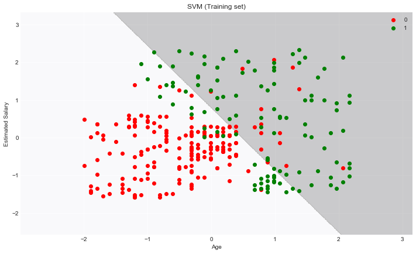

```python
# Visualising the Training set results
from matplotlib.colors import ListedColormap
plt.figure(figsize=(12,7))
X_set, y_set = X_train, y_train
X1, X2 = np.meshgrid(np.arange(start = X_set[:, 0].min() - 1, stop = X_set[:, 0].max() + 1, step = 0.01),
                     np.arange(start = X_set[:, 1].min() - 1, stop = X_set[:, 1].max() + 1, step = 0.01))
plt.contourf(X1, X2, classifier.predict(np.array([X1.ravel(), X2.ravel()]).T).reshape(X1.shape),
             alpha = 0.75,
             cmap = ListedColormap(('white', 'silver'))
            )
plt.xlim(X1.min(), X1.max())
plt.ylim(X2.min(), X2.max())
for i, j in enumerate(np.unique(y_set)):
    plt.scatter(X_set[y_set == j, 0], X_set[y_set == j, 1],
               c = ListedColormap(('red', 'green'))(i),
                label = j)
plt.title('SVM (Training set)')
plt.xlabel('Age')
plt.ylabel('Estimated Salary')
plt.legend()
plt.show()
```

[output not shown]

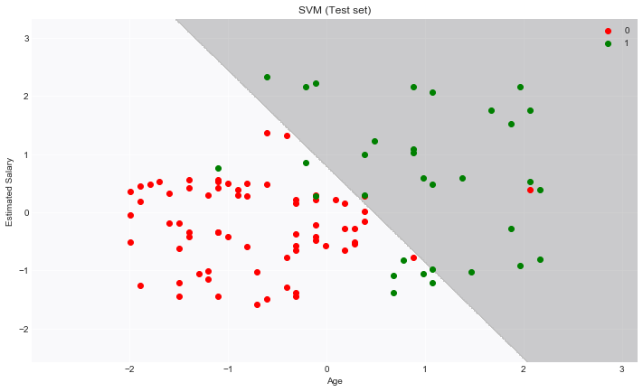

```python
# Visualising the Test set results
from matplotlib.colors import ListedColormap
plt.figure(figsize=(12,7))
X_set, y_set = X_test, y_test
X1, X2 = np.meshgrid(np.arange(start = X_set[:, 0].min() - 1, stop = X_set[:, 0].max() + 1, step = 0.01),
                     np.arange(start = X_set[:, 1].min() - 1, stop = X_set[:, 1].max() + 1, step = 0.01))
plt.contourf(X1, X2, classifier.predict(np.array([X1.ravel(), X2.ravel()]).T).reshape(X1.shape),
             alpha = 0.75,
             cmap = ListedColormap(('white', 'silver'))
            )
plt.xlim(X1.min(), X1.max())
plt.ylim(X2.min(), X2.max())
for i, j in enumerate(np.unique(y_set)):
    plt.scatter(X_set[y_set == j, 0], X_set[y_set == j, 1],
               c = ListedColormap(('red', 'green'))(i),
                label = j)
plt.title('SVM (Test set)')
plt.xlabel('Age')
plt.ylabel('Estimated Salary')
plt.legend()
plt.show()
```

# Kernal Support Vector Machine (SVM)

A major drawback of a traditional SVM is its linearity. Data is often more accurately separated through non-linear devision. Imagine, for example, a dataset wherein one category is completely surrounded by another, clearly linear separation is inappropriate.

## Higher Dimensional Linear Devision

Mathematically, it is always possible to transform a dataset to a higher dimensional space & then separate categories linearly. Continuing with the abovemetioned example, the dataset could be converted to a higher diminensional mapping, thereafter the inner category would rise much higher than the outter category and is readily separated with a linear hyperplane.

This higher dimensional process is often infeasible as it is too computationally expensive. The *kernal* trick offers an inexpensive equivolent.

## The Kernal Trick

The data is converted to a Guassian Kernal (spherical Guassian) - based on the distance of each datapoint from an optimally chosen midpoint. Thereafter selecting the correct $\sigma$ in $\sim \mathcal{N}(\mu, \sigma)$ accounts for the spread of the distribution. More complecated datasets can be modelled leveraging multiple Gaussian Kernals to capture asymmetrical, non-linear datasets.

The key takeaway is that a non-linear, optimal devision is found without extrapolating the data into a higher dimensional space.

We are not limited to a Gaussian kernal. Other popular choices include the *Sigmoid* kernal & *Polynomial* Kernal - both of which essentially capture the distance from the centroid.

Futher reading on Kernal mechanics: https://pdfs.semanticscholar.org/f8a9/51ce919dca7dea476b3a508b2c322a2814f9.pdf

```python
# Importing the dataset
dataset = pd.read_csv('Social_Network_Ads.csv')
X = dataset.iloc[:, [2, 3]].values
y = dataset.iloc[:, 4].values

# Splitting the dataset into the Training set and Test set
from sklearn.model_selection import train_test_split
X_train, X_test, y_train, y_test = train_test_split(X, y, test_size = 0.25, random_state = 0)

# Feature Scaling
from sklearn.preprocessing import StandardScaler
sc = StandardScaler()
X_train = sc.fit_transform(X_train)
X_test = sc.transform(X_test)

print('')
print('shape: ', dataset.shape)
print('')
print(dataset.head())
```

```
shape:  (400, 5)

    User ID  Gender  Age  EstimatedSalary  Purchased
0  15624510    Male   19            19000          0
1  15810944    Male   35            20000          0
2  15668575  Female   26            43000          0
3  15603246  Female   27            57000          0
4  15804002    Male   19            76000          0
```

```python
# Fitting Kernel SVM to the Training set
from sklearn.svm import SVC
classifier = SVC(kernel = 'rbf', random_state = 0)
classifier.fit(X_train, y_train)

# Predicting the Test set results
y_pred = classifier.predict(X_test)

# Making the Confusion Matrix
from sklearn.metrics import confusion_matrix
cm = confusion_matrix(y_test, y_pred)

print('')
print('confusion matrix: ')
print('')
print(cm)
```

```
confusion matrix:

[[64  4]
 [ 3 29]]
```

[output not shown]

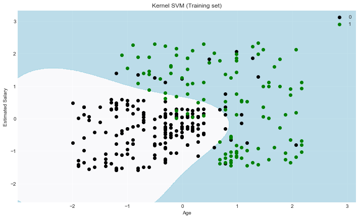

```python
# Visualising the Training set results
from matplotlib.colors import ListedColormap
plt.figure(figsize=(12,7))
X_set, y_set = X_train, y_train
X1, X2 = np.meshgrid(np.arange(start = X_set[:, 0].min() - 1, stop = X_set[:, 0].max() + 1, step = 0.01),
                     np.arange(start = X_set[:, 1].min() - 1, stop = X_set[:, 1].max() + 1, step = 0.01))
plt.contourf(X1, X2, classifier.predict(np.array([X1.ravel(), X2.ravel()]).T).reshape(X1.shape),
             alpha = 0.75,
             cmap = ListedColormap(('white', 'lightblue'))
            )
plt.xlim(X1.min(), X1.max())
plt.ylim(X2.min(), X2.max())
for i, j in enumerate(np.unique(y_set)):
    plt.scatter(X_set[y_set == j, 0], X_set[y_set == j, 1],
                c = ListedColormap(('black', 'green'))(i),
                label = j)
plt.title('Kernel SVM (Training set)')
plt.xlabel('Age')
plt.ylabel('Estimated Salary')
plt.legend()
plt.show()
```

[output not shown]

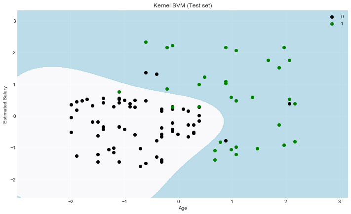

```python
# Visualising the Test set results
from matplotlib.colors import ListedColormap
plt.figure(figsize=(12,7))
X_set, y_set = X_test, y_test
X1, X2 = np.meshgrid(np.arange(start = X_set[:, 0].min() - 1, stop = X_set[:, 0].max() + 1, step = 0.01),
                     np.arange(start = X_set[:, 1].min() - 1, stop = X_set[:, 1].max() + 1, step = 0.01))
plt.contourf(X1, X2, classifier.predict(np.array([X1.ravel(), X2.ravel()]).T).reshape(X1.shape),
             alpha = 0.75,
             cmap = ListedColormap(('white', 'lightblue'))
            )
plt.xlim(X1.min(), X1.max())
plt.ylim(X2.min(), X2.max())
for i, j in enumerate(np.unique(y_set)):
    plt.scatter(X_set[y_set == j, 0], X_set[y_set == j, 1],
                c = ListedColormap(('black', 'green'))(i),
                label = j)
plt.title('Kernel SVM (Test set)')
plt.xlabel('Age')
plt.ylabel('Estimated Salary')
plt.legend()
plt.show()
```

# Naive Bayes

A Bayesian, probabilistic, approach to classification.

Suppose there are two categories & we are given a new datapoint:

## Step 1

Calculate the probability that a new datapoint is an example of category 1 given its features:

$$P(\hat{Y}=1|X) = \frac{P(X|\hat{Y}=1)*P(\hat{Y}=1)}{P(X)}$$

## Step 2

Calculate the probability that a new datapoint is an example of category 2 given its features:

$$P(\hat{Y}=2|X) = \frac{P(X|\hat{Y}=2)*P(\hat{Y}=2)}{P(X)}$$

## Diagnostics:

Prior: unconditional probability of $\hat{Y}$

Marginal Likelihood:

```
- place a radius arround the new datapoint
- consider all the existing datapoints inside the radius as 'similar' to the new datapoint
- therefor, P(x) can be calulated as the probability of a datapoint being similar to those in the radius, thus is calculated by P(x) = (no. of points in radius / total obervations)
```

Likelihood:

```
- again consider all points in the radius
- calculate the likelihood that the datapoint has features X, given it is of category K.
- P(X|y) = (no. of points in radius in category K / no. of points in radius)
```

## Step 3

Once both probabilities are calculated, the algorithm classifies the new point as whichever category offers the highest probability. Clearly if there are two probabilities, calculating only 1 will suffice. Similarly, if there are $K$ categories only $K-1$ need be calculated.

## Additional Notes:

### Why is it called Naive Bayes

Bayes theorem relies on some relies on the *Independence* assumption, it is often *Naive* to do so.

### Computational Efficiency

Since we are comparing two Bayesian probabilities, it is sufficent to simply compute the numerators, as denominators cancle out - saving computational effort.

```python
# Importing the dataset
dataset = pd.read_csv('Social_Network_Ads.csv')
X = dataset.iloc[:, [2, 3]].values
y = dataset.iloc[:, 4].values
```

```python
dataset.info()
dataset.head()
```

```
<class 'pandas.core.frame.DataFrame'>
RangeIndex: 400 entries, 0 to 399
Data columns (total 5 columns):
User ID            400 non-null int64
Gender             400 non-null object
Age                400 non-null int64
EstimatedSalary    400 non-null int64
Purchased          400 non-null int64
dtypes: int64(4), object(1)
memory usage: 15.7+ KB
```

|  | User ID | Gender | Age | EstimatedSalary | Purchased |
| --- | --- | --- | --- | --- | --- |
| 0 | 15624510 | Male | 19 | 19000 | 0 |
| 1 | 15810944 | Male | 35 | 20000 | 0 |
| 2 | 15668575 | Female | 26 | 43000 | 0 |
| 3 | 15603246 | Female | 27 | 57000 | 0 |
| 4 | 15804002 | Male | 19 | 76000 | 0 |

```python
# Splitting the dataset into the Training set and Test set
from sklearn.model_selection import train_test_split
X_train, X_test, y_train, y_test = train_test_split(X, y, test_size = 0.25, random_state = 0)


# Feature Scaling
from sklearn.preprocessing import StandardScaler
sc = StandardScaler()
X_train = sc.fit_transform(X_train)
X_test = sc.transform(X_test)


# Fitting Naive Bayes to the Training set
from sklearn.naive_bayes import GaussianNB
classifier = GaussianNB()
classifier.fit(X_train, y_train)

# Predicting the Test set results
y_pred = classifier.predict(X_test)

# Making the Confusion Matrix
from sklearn.metrics import confusion_matrix
cm = confusion_matrix(y_test, y_pred)
print('confusion matrix: ')
print('')
print(cm)
```

```
confusion matrix:

[[65  3]
 [ 7 25]]
```

[output not shown]

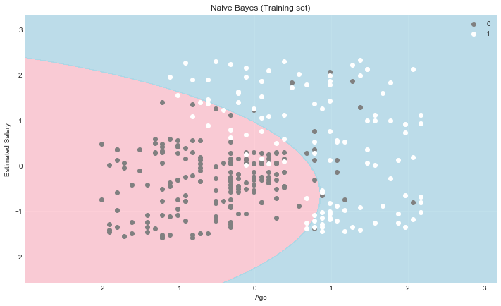

```python
# Visualising the Training set results
from matplotlib.colors import ListedColormap
plt.figure(figsize=(12,7))
X_set, y_set = X_train, y_train
X1, X2 = np.meshgrid(np.arange(start = X_set[:, 0].min() - 1, stop = X_set[:, 0].max() + 1, step = 0.01),
                     np.arange(start = X_set[:, 1].min() - 1, stop = X_set[:, 1].max() + 1, step = 0.01))
plt.contourf(X1, X2, classifier.predict(np.array([X1.ravel(), X2.ravel()]).T).reshape(X1.shape),
             alpha = 0.75, cmap = ListedColormap(('pink', 'lightblue')))
plt.xlim(X1.min(), X1.max())
plt.ylim(X2.min(), X2.max())
for i, j in enumerate(np.unique(y_set)):
    plt.scatter(X_set[y_set == j, 0], X_set[y_set == j, 1],
                c = ListedColormap(('grey', 'white'))(i), label = j)
plt.title('Naive Bayes (Training set)')
plt.xlabel('Age')
plt.ylabel('Estimated Salary')
plt.legend()
plt.show()
```

[output not shown]

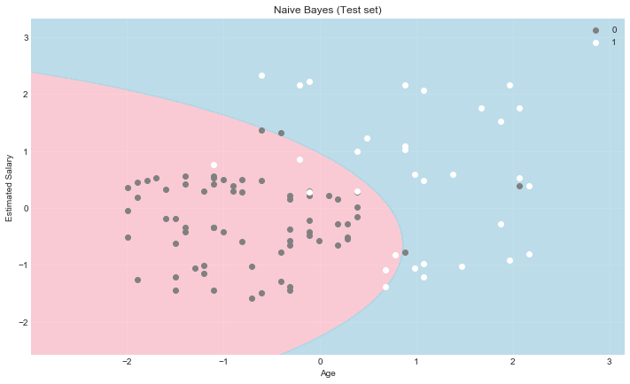

```python
# Visualising the Test set results
from matplotlib.colors import ListedColormap
plt.figure(figsize=(12,7))
X_set, y_set = X_test, y_test
X1, X2 = np.meshgrid(np.arange(start = X_set[:, 0].min() - 1, stop = X_set[:, 0].max() + 1, step = 0.01),
                     np.arange(start = X_set[:, 1].min() - 1, stop = X_set[:, 1].max() + 1, step = 0.01))
plt.contourf(X1, X2, classifier.predict(np.array([X1.ravel(), X2.ravel()]).T).reshape(X1.shape),
             alpha = 0.75,  cmap = ListedColormap(('pink', 'lightblue')))
plt.xlim(X1.min(), X1.max())
plt.ylim(X2.min(), X2.max())
for i, j in enumerate(np.unique(y_set)):
    plt.scatter(X_set[y_set == j, 0], X_set[y_set == j, 1],
                c = ListedColormap(('grey', 'white'))(i), label = j)
plt.title('Naive Bayes (Test set)')
plt.xlabel('Age')
plt.ylabel('Estimated Salary')
plt.legend()
plt.show()
```

# Decision Tree Classifier

Perform a series of linear separations to split the data. The splits are done as to maximize the number in each category after the split - a split attempts to minimize infomational entropy.

### Notes:

If too expensive to search the entire tree, a probabilistic approach can be used to classify datapoints at higher (not at the terminal) nodes - wherein the probability of each category is calculated at a higher node.

Caveat: setting too many decision boundaries will result in overfitting.

Decision trees lost favour in the ML community, but has seen a resergence as slightly more elaborate variation of the algorithm (like Random Forest & Gradient Boosting) has proven very useful.

```python
# Importing the dataset
dataset = pd.read_csv('Social_Network_Ads.csv')
X = dataset.iloc[:, [2, 3]].values
y = dataset.iloc[:, 4].values

dataset.head()
```

|  | User ID | Gender | Age | EstimatedSalary | Purchased |
| --- | --- | --- | --- | --- | --- |
| 0 | 15624510 | Male | 19 | 19000 | 0 |
| 1 | 15810944 | Male | 35 | 20000 | 0 |
| 2 | 15668575 | Female | 26 | 43000 | 0 |
| 3 | 15603246 | Female | 27 | 57000 | 0 |
| 4 | 15804002 | Male | 19 | 76000 | 0 |

```python
# Splitting the dataset into the Training set and Test set
from sklearn.model_selection import train_test_split
X_train, X_test, y_train, y_test = train_test_split(X, y, test_size = 0.25, random_state = 0)

# Feature Scaling
from sklearn.preprocessing import StandardScaler
sc = StandardScaler()
X_train = sc.fit_transform(X_train)
X_test = sc.transform(X_test)

# Fitting Decision Tree Classification to the Training set
from sklearn.tree import DecisionTreeClassifier
classifier = DecisionTreeClassifier(criterion = 'entropy', random_state = 0)
classifier.fit(X_train, y_train)

# Predicting the Test set results
y_pred = classifier.predict(X_test)

# Making the Confusion Matrix
from sklearn.metrics import confusion_matrix
cm = confusion_matrix(y_test, y_pred)
print('confusion matrix:')
print('')
print(cm)
```

```
confusion matrix:

[[62  6]
 [ 3 29]]
```

[output not shown]

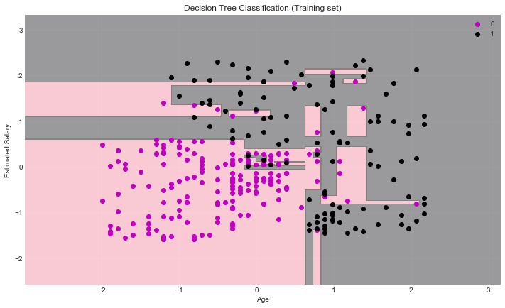

```python
# Visualising the Training set results
from matplotlib.colors import ListedColormap
plt.figure(figsize=(12,7))

X_set, y_set = X_train, y_train
X1, X2 = np.meshgrid(np.arange(start = X_set[:, 0].min() - 1, stop = X_set[:, 0].max() + 1, step = 0.01),
                     np.arange(start = X_set[:, 1].min() - 1, stop = X_set[:, 1].max() + 1, step = 0.01))
plt.contourf(X1, X2, classifier.predict(np.array([X1.ravel(), X2.ravel()]).T).reshape(X1.shape),
             alpha = 0.75, cmap = ListedColormap(('pink', 'grey')))
plt.xlim(X1.min(), X1.max())
plt.ylim(X2.min(), X2.max())
for i, j in enumerate(np.unique(y_set)):
    plt.scatter(X_set[y_set == j, 0], X_set[y_set == j, 1],
                c = ListedColormap(('m', 'black'))(i), label = j)
plt.title('Decision Tree Classification (Training set)')
plt.xlabel('Age')
plt.ylabel('Estimated Salary')
plt.legend()
plt.show()
```

[output not shown]

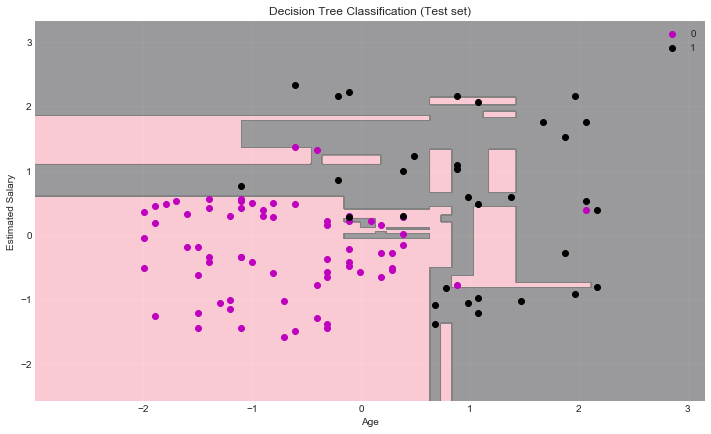

```python
# Visualising the Test set results
from matplotlib.colors import ListedColormap
plt.figure(figsize=(12,7))
X_set, y_set = X_test, y_test
X1, X2 = np.meshgrid(np.arange(start = X_set[:, 0].min() - 1, stop = X_set[:, 0].max() + 1, step = 0.01),
                     np.arange(start = X_set[:, 1].min() - 1, stop = X_set[:, 1].max() + 1, step = 0.01))
plt.contourf(X1, X2, classifier.predict(np.array([X1.ravel(), X2.ravel()]).T).reshape(X1.shape),
             alpha = 0.75, cmap = ListedColormap(('pink', 'grey')))
plt.xlim(X1.min(), X1.max())
plt.ylim(X2.min(), X2.max())
for i, j in enumerate(np.unique(y_set)):
    plt.scatter(X_set[y_set == j, 0], X_set[y_set == j, 1],
                c = ListedColormap(('m', 'black'))(i), label = j)
plt.title('Decision Tree Classification (Test set)')
plt.xlabel('Age')
plt.ylabel('Estimated Salary')
plt.legend()
plt.show()
```

# Random Forest

## Ensamble Learning

Ensample learning is the practice of combining multiple learning algorithms to form a new, more comprehensive, algorithm.

## Random Forest Algorithm

```
- Pick a random subset of size K from the data
- Build a decision tree associated with the K points
- Choose n: the number of trees to compute
- Repeat steps 1 & 2 n times
- Prediction of a new datapoint is then done by making each tree PREDICT the category, & thereafter assign the datapoint to the category that wins the majority vote.
```

The power of number can eradicate erroneous results and improve performance - despite at the cost of computation.

#### Trivia:

Microsoft used Random Forest for body movement detection in some of its video games:

https://www.microsoft.com/en-us/research/wp-content/uploads/2016/02/BodyPartRecognition.pdf

```python
# Importing the dataset
dataset = pd.read_csv('Social_Network_Ads.csv')
X = dataset.iloc[:, [2, 3]].values
y = dataset.iloc[:, 4].values

print('')
print('Shape: ', dataset.shape)
print('')
print(dataset.head())
```

```
Shape:  (400, 5)

    User ID  Gender  Age  EstimatedSalary  Purchased
0  15624510    Male   19            19000          0
1  15810944    Male   35            20000          0
2  15668575  Female   26            43000          0
3  15603246  Female   27            57000          0
4  15804002    Male   19            76000          0
```

```python
# Splitting the dataset into the Training set and Test set
from sklearn.model_selection import train_test_split
X_train, X_test, y_train, y_test = train_test_split(X, y, test_size = 0.25, random_state = 0)

# Feature Scaling
from sklearn.preprocessing import StandardScaler
sc = StandardScaler()
X_train = sc.fit_transform(X_train)
X_test = sc.transform(X_test)

# Fitting Random Forest Classification to the Training set
from sklearn.ensemble import RandomForestClassifier
classifier = RandomForestClassifier(n_estimators = 10, criterion = 'entropy', random_state = 0)
classifier.fit(X_train, y_train)

# Predicting the Test set results
y_pred = classifier.predict(X_test)

# Making the Confusion Matrix
from sklearn.metrics import confusion_matrix
cm = confusion_matrix(y_test, y_pred)

print('Confusion matrix:')
print('')
print(cm)
```

```
Confusion matrix:

[[63  5]
 [ 4 28]]
```

[output not shown]

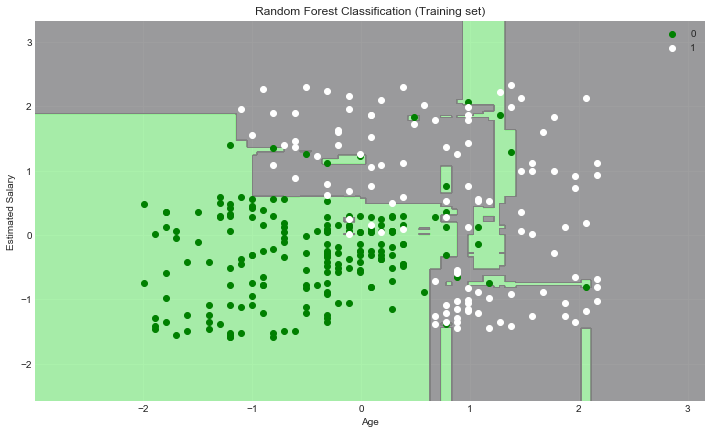

```python
# Visualising the Training set results
from matplotlib.colors import ListedColormap
plt.figure(figsize=(12,7))
X_set, y_set = X_train, y_train
X1, X2 = np.meshgrid(np.arange(start = X_set[:, 0].min() - 1, stop = X_set[:, 0].max() + 1, step = 0.01),
                     np.arange(start = X_set[:, 1].min() - 1, stop = X_set[:, 1].max() + 1, step = 0.01))
plt.contourf(X1, X2, classifier.predict(np.array([X1.ravel(), X2.ravel()]).T).reshape(X1.shape),
             alpha = 0.75, cmap = ListedColormap(('lightgreen', 'grey')))
plt.xlim(X1.min(), X1.max())
plt.ylim(X2.min(), X2.max())
for i, j in enumerate(np.unique(y_set)):
    plt.scatter(X_set[y_set == j, 0], X_set[y_set == j, 1],
                c = ListedColormap(('green', 'white'))(i), label = j)
plt.title('Random Forest Classification (Training set)')
plt.xlabel('Age')
plt.ylabel('Estimated Salary')
plt.legend()
plt.show()
```

[output not shown]

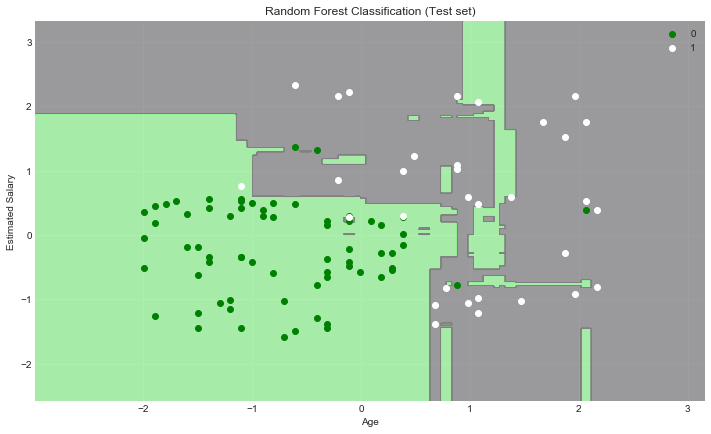

```python
# Visualising the Test set results
from matplotlib.colors import ListedColormap
plt.figure(figsize=(12,7))
X_set, y_set = X_test, y_test
X1, X2 = np.meshgrid(np.arange(start = X_set[:, 0].min() - 1, stop = X_set[:, 0].max() + 1, step = 0.01),
                     np.arange(start = X_set[:, 1].min() - 1, stop = X_set[:, 1].max() + 1, step = 0.01))
plt.contourf(X1, X2, classifier.predict(np.array([X1.ravel(), X2.ravel()]).T).reshape(X1.shape),
             alpha = 0.75, cmap = ListedColormap(('lightgreen', 'grey')))
plt.xlim(X1.min(), X1.max())
plt.ylim(X2.min(), X2.max())
for i, j in enumerate(np.unique(y_set)):
    plt.scatter(X_set[y_set == j, 0], X_set[y_set == j, 1],
                c = ListedColormap(('green', 'white'))(i), label = j)
plt.title('Random Forest Classification (Test set)')
plt.xlabel('Age')
plt.ylabel('Estimated Salary')
plt.legend()
plt.show()
```

# Model Evaluation

## Type 1 & Type 2 Errors

```
- True Positive
- True Negative
- False Positive (Type 1 Error)
- False Negative (Type 2 Error)
```

#### False Postive: Type 1 Error:

Predicted True - that did not occur

#### False Negative: Type 2 Error:

Predicted False - that did occur

## Confusion Matrix

Gives the frequency of *actual* vs *predicted* values, indicating: TP, TN, FP, FN. Sklearn confusion matrix is given as: (with reference to table) Top index: $\hat{Y}$: Predicted values Left index: $Y$: Actual values

Thus indicating:

TN | FP

FN | TP

## Accuracy:

Accuracy Paradox: The accuracy rate can be misleading, as in the case of extreme value data.

$Total = TN + FN + TP + FP$

Accuracy Rate: $$ \frac{TP + TN}{total}$$

Error Rate: $$ \frac{FP + FN}{total}$$

## Sensitivity & Specificity

(in terms of actual - not predicted - to form the base)

Sensitivity: $$\frac{TP}{TP + FN}$$

Specificity: $$\frac{TN}{TN + FP}$$

## Next

Try CAP curve analysis & ROC curve analysis.

```python
# Making the Confusion Matrix
from sklearn.metrics import confusion_matrix
cm = confusion_matrix(y_test, y_pred)

print('Confusion matrix:')
print('')
print(cm)

# Accuracy & Error Rate
total = np.sum(cm)
accuracy = (cm[0][0] + cm[1][1]) / total
error = (cm[1][0] + cm[0][1]) / total
print('')
print('accuracy rate: ', accuracy)
print('error rate: ', error)


# Sensitivity & Specificity

sensitivity = cm[1][1] / np.sum(cm[1])
specificity = cm[0][0] / np.sum(cm[0])
print('')
print('sensitivity: ', sensitivity)
print('specificity: ', specificity)
```

```
Confusion matrix:

[[63  5]
 [ 4 28]]

accuracy rate:  0.91
error rate:  0.09

sensitivity:  0.875
specificity:  0.9264705882352942
```